# Assignment09_Summer19_Grace_Lang_v2

Grace Lang

7/8/2019

# A1-5) Clean and Prepare the data:

```r
library(dplyr)
library(tidyverse)
```

```r
library(ggplot2)
library(stats)
library(caret)
library(rmarkdown)
library(tinytex)

#Loading the two files
BeersCSV <- "https://raw.githubusercontent.com/BivinSadler/MSDS-6306-Doing-Data-Science/master/Unit%207/Beers.csv"
Beers <- read.csv(url(BeersCSV))

BrewCSV <- "https://raw.githubusercontent.com/BivinSadler/MSDS-6306-Doing-Data-Science/master/Unit%207/Breweries.csv"
Brew <- read.csv(url(BrewCSV))

#Merging the two files
colnames(Beers)[colnames(Beers)=="Brewery_id"] <- "Brew_ID" #Rename for the same key
Combined <- merge(Beers, Brew, by = "Brew_ID") # Merge files
colnames(Combined)[colnames(Combined)=="Name.x"] <- "Beer Name"
colnames(Combined)[colnames(Combined)=="Name.y"] <- "Brewery_Name"

##Check to see where spaces fall
#head(paste(Combined$State),5)

#Create a function for trimming states
trim <- function(x) { gsub("(^[[:space:]]+|[[:space:]]+$)", "", x) }
Combined_Trimmed <- Combined[,1:9]
Trimmed_State <- data.frame(State = trim(Combined$State))
Combined <- cbind(Combined_Trimmed,Trimmed_State)

##Check to ensure spaces are gone
#head(paste(Combined$State),5)

#One dataset with no IBU/NAs and only filter on TX & CO
beerCOTX <- Combined %>% subset.data.frame(State == c("CO","TX")) %>% arrange(IBU) %>% na.omit()
```

# B6) Create an initial plot of the data

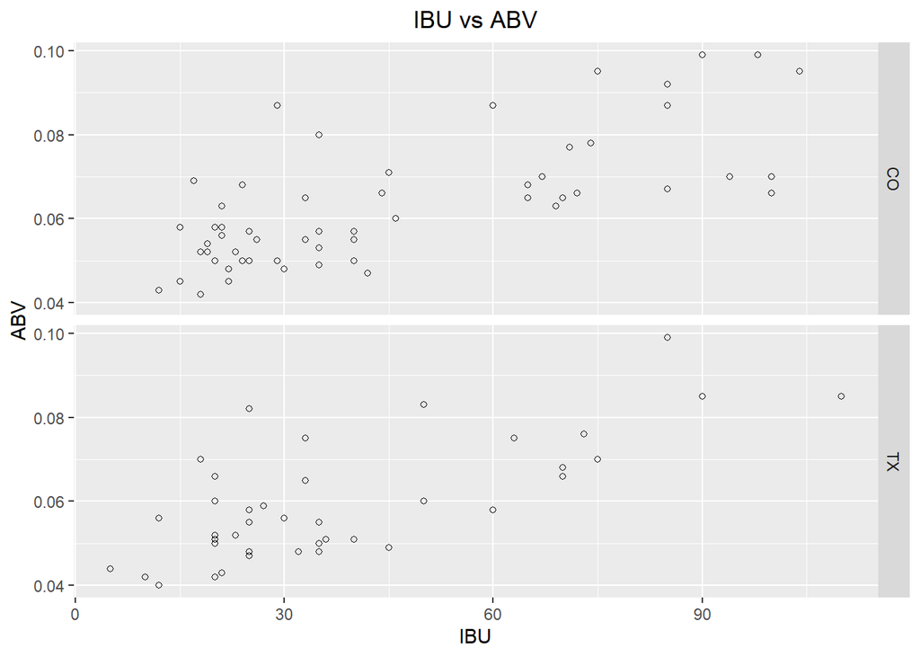

```r
#Plot
ggplot(beerCOTX, aes(x=IBU, y=ABV)) +
    geom_point(shape=1) +    # Use hollow circles
    facet_grid(rows= vars(State)) +
    theme_grey() +
    theme(plot.title = element_text(hjust=0.5)) + labs(x="IBU", y="ABV", title = "IBU vs ABV")
```

# C7) Model the data

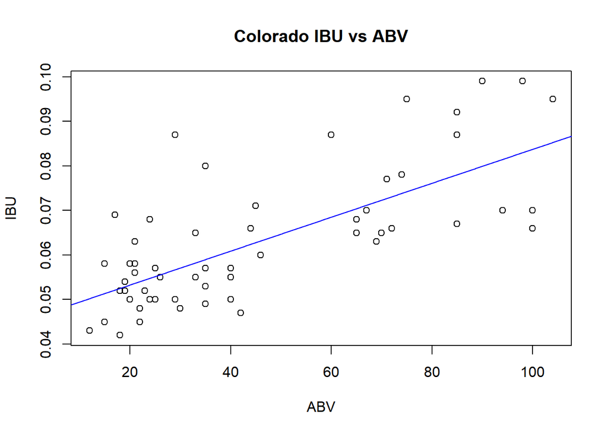

```
## integer(0)
```

```r
#Plot regression line for each state
beerCO <- subset.data.frame(beerCOTX, State == "CO")
beerTX <- subset.data.frame(beerCOTX, State == "TX")

regCO <- lm(ABV~IBU, data = beerCO)
plot(ABV~IBU, data =beerCO, main = "Colorado IBU vs ABV", xlab= 'ABV', ylab = 'IBU') + abline(regCO, col="blue")
```

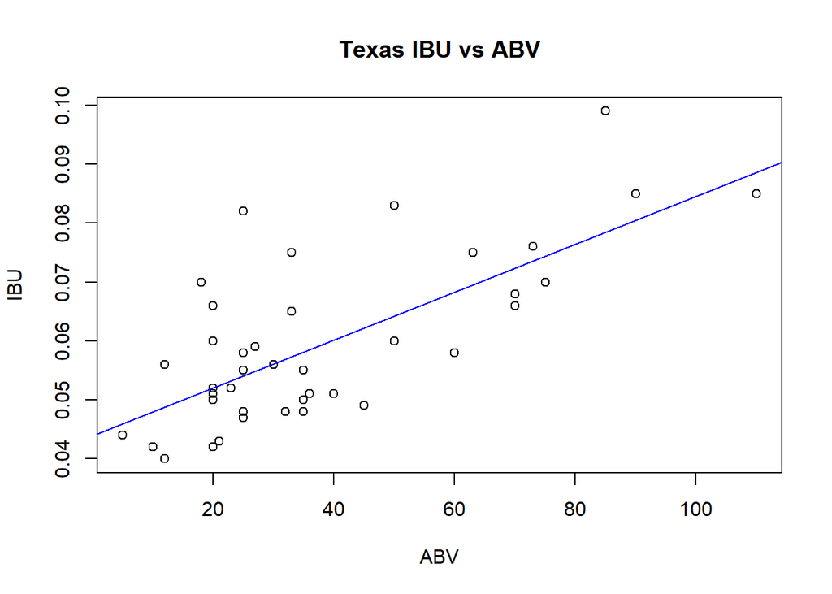

```
## integer(0)
```

```r
regTX <- lm(ABV~IBU, data = beerTX)
plot(ABV~IBU, data =beerTX, main = "Texas IBU vs ABV", xlab= 'ABV', ylab = 'IBU') + abline(regTX, col="blue")
```

```r
#Faceted GGPlot for reference
#ggplot(beerCOTX, aes(x=IBU, y=ABV)) +
#    geom_point(shape=1) +    # Use hollow circles
#    geom_smooth(method = "lm") +
#    facet_grid(rows= vars(State)) +
#    theme_grey() +
#    theme(plot.title = element_text(hjust=0.5)) + labs(x="IBU", y="ABV", title = "IBU vs ABV")
```

## C8) Assumptions of the regression model:

```
 1. There is a normal distribution of the ABV for fixed values of IBU
```

No, the data is right skewed for both TX & CO. There does not appear to be evidence of normal distribution.

```
2. These normal distributions have equal standard deviations.
```

No, based on the residual graph, the residuals do not have a consistent variance.

```
3. The means of these normal distributions have a linear relationship with IBU.
```

```
4. Independence (you may assume this one to be true without defense.)
```

The observations are independent of one another for CO & TX.

# D8) Gain inference from the model

The residuals look like a random cloud; however, they do not seem to have a constant variance.

### 9) Interpret the Slope

With the increase in IBU, there is an associated increase in mean ABV by 3.805e-04 for Colorado and an increase in mean ABV by 4.066e-04 for Texas.

### 9) Is there evidence that the relationship between ABV and IBU is significantly different for Texas and Colorado beers?

Both Texas and Colorado have right-skewed distributions; however, based on the outputs there does not seem to be a significant difference between the two.

### 10) Provide a confidence interval for each slope.

Colorado: The model shows 95% confidence that the associated increase of ABV with an increase in IBU is between 0.00029 and 0.00047.

Texas: The model shows 95% confidence that the associated increase of ABV with an increase in IBU is between 0.00030 and 0.00052.

```r
summary(regCO)
```

```
##
## Call:
## lm(formula = ABV ~ IBU, data = beerCO)
##
## Residuals:
##       Min        1Q    Median        3Q       Max
## -0.017700 -0.006186 -0.003204  0.004553  0.030319
##
## Coefficients:
##              Estimate Std. Error t value Pr(>|t|)
## (Intercept) 4.565e-02  2.416e-03  18.893  < 2e-16 ***
## IBU         3.805e-04  4.502e-05   8.452 2.98e-12 ***
## ---
## Signif. codes:  0 '***' 0.001 '**' 0.01 '*' 0.05 '.' 0.1 ' ' 1
##
## Residual standard error: 0.009969 on 69 degrees of freedom
## Multiple R-squared:  0.5087, Adjusted R-squared:  0.5016
## F-statistic: 71.44 on 1 and 69 DF,  p-value: 2.98e-12
```

```r
summary(regTX)
```

```
##
## Call:
## lm(formula = ABV ~ IBU, data = beerTX)
##
## Residuals:
##       Min        1Q    Median        3Q       Max
## -0.013241 -0.006405 -0.002077  0.004077  0.027890
##
## Coefficients:
##              Estimate Std. Error t value Pr(>|t|)
## (Intercept) 4.395e-02  2.520e-03  17.439  < 2e-16 ***
## IBU         4.066e-04  5.468e-05   7.435 3.04e-09 ***
## ---
## Signif. codes:  0 '***' 0.001 '**' 0.01 '*' 0.05 '.' 0.1 ' ' 1
##
## Residual standard error: 0.009527 on 43 degrees of freedom
## Multiple R-squared:  0.5625, Adjusted R-squared:  0.5523
## F-statistic: 55.27 on 1 and 43 DF,  p-value: 3.037e-09
```

```r
confint(regCO)
```

```
##                    2.5 %       97.5 %
## (Intercept) 0.0408258288 0.0504656245
## IBU         0.0002907207 0.0004703591
```

```r
confint(regTX)
```

```
##                    2.5 %       97.5 %
## (Intercept) 0.0388637286 0.0490276337
## IBU         0.0002962819 0.0005168464
```

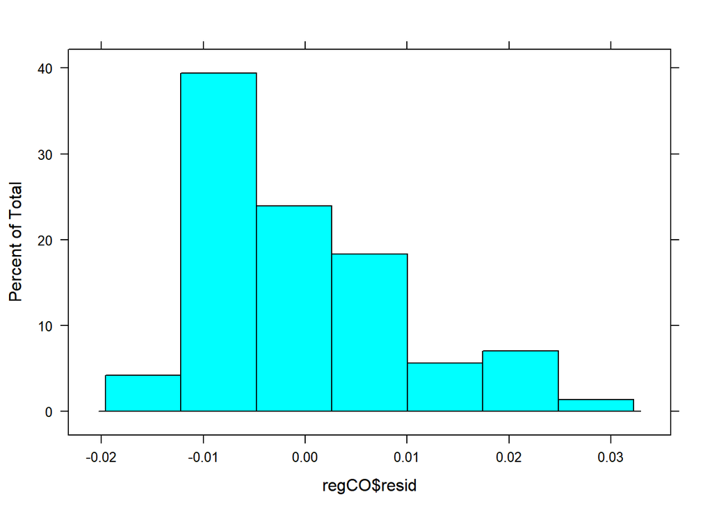

```r
#Each individual residuals for data
#regCO$resid
#regTX$resid

#Are the residuals normal
histogram(regCO$resid)
```

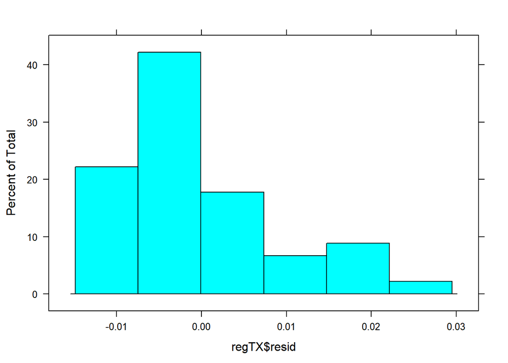

```r
histogram(regTX$resid)
```

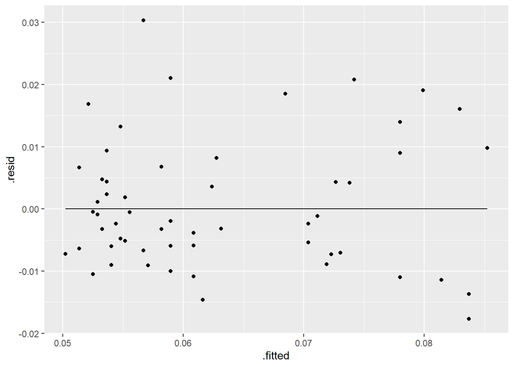

```r
#Do the residuals have a constant variance
ggplot(regCO, aes(x=.fitted,y=.resid)) +geom_point() + geom_line(aes(y=0))
```

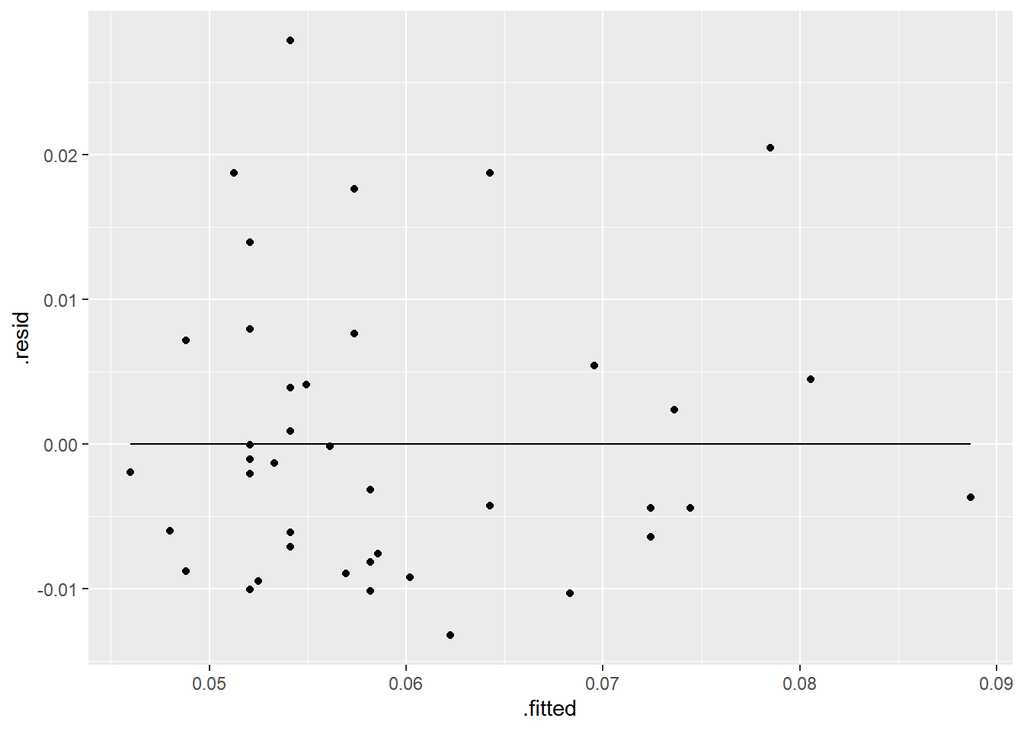

```r
ggplot(regTX, aes(x=.fitted,y=.resid)) +geom_point() + geom_line(aes(y=0))
```

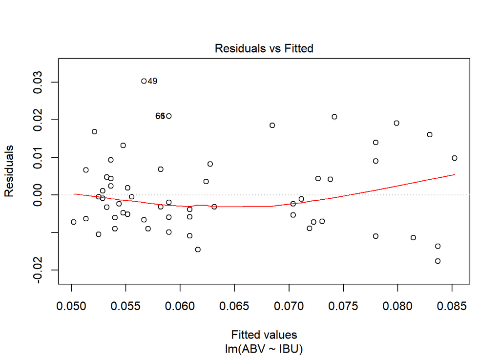

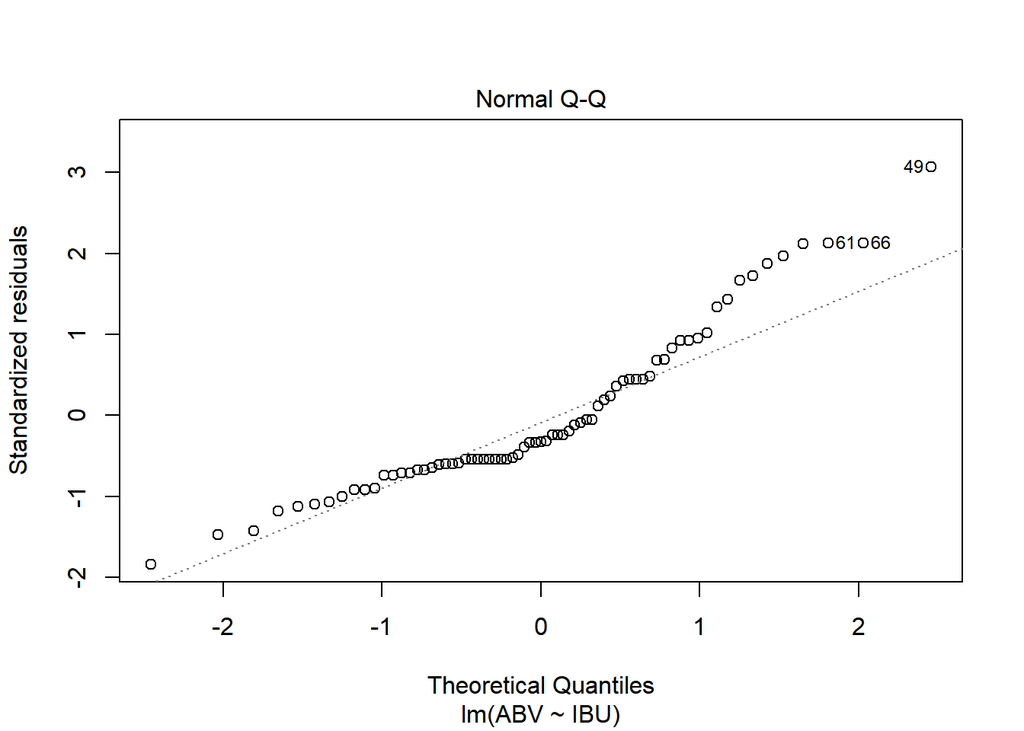

```r
plot(regCO, which=1:2)
```

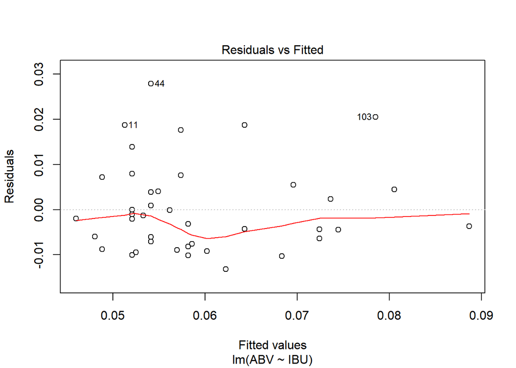

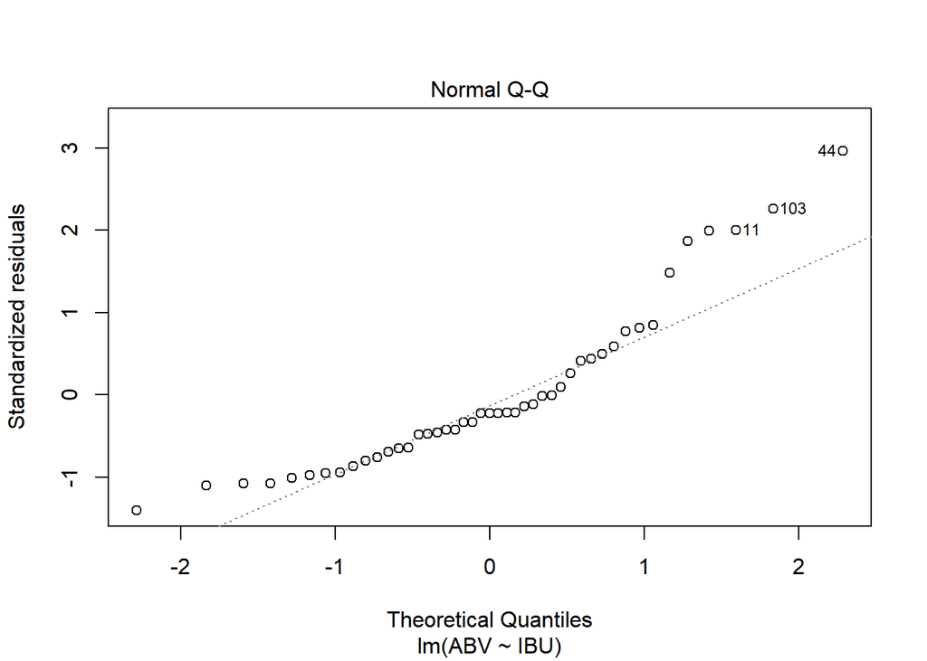

```r
plot(regTX, which=1:2)
```

# E) Compare two competing models: External Cross Validation

```r
beerCOTX_log = beerCOTX %>% mutate(IBU2 = IBU^2)
head(beerCOTX_log,5)
```

```
##   Brew_ID             Beer Name Beer_ID   ABV IBU              Style
## 1      67    Yo Soy Un Berliner    2520 0.044   5 Berliner Weissbier
## 2     129 18th Anniversary Gose    2370 0.044   5               Gose
## 3      67               Rye Wit    2522 0.042  10            Witbier
## 4     188             Lobo Lito    2238 0.040  12        Light Lager
## 5     216         Broken Bridge    2117 0.056  12       Dunkelweizen
##   Ounces               Brewery_Name           City State IBU2
## 1     12   Freetail Brewing Company    San Antonio    TX   25
## 2     12   Real Ale Brewing Company         Blanco    TX   25
## 3     12   Freetail Brewing Company    San Antonio    TX  100
## 4     12 Pedernales Brewing Company Fredericksburg    TX  144
## 5     12         Texian Brewing Co.       Richmond    TX  144
```

```r
beerCO_2 <- subset.data.frame(beerCOTX_log, State == "CO")
beerTX_2 <- subset.data.frame(beerCOTX_log, State == "TX")

#Training datasets
set.seed(1)

TrainCO = sample(seq(1,dim(beerCO_2)[1]),round(.60*dim(beerCO_2)[1]),replace = FALSE)
CO_Train = beerCO_2[TrainCO,]
#CO_Train
CO_Test = beerCO_2[-TrainCO,]
#CO_Test

TrainTX = sample(seq(1,dim(beerTX_2)[1]),round(.60*dim(beerTX_2)[1]),replace = FALSE)
TX_Train = beerTX_2[TrainTX,]
#TX_Train
TX_Test = beerTX_2[-TrainTX,]
#TX_Test

#degrees of freedom
#nrow(CO_Train) #43
#nrow(TX_Train) #27



#CO linear
CO_1_fit <- lm(ABV~IBU, data = CO_Train)
summary(CO_1_fit)
```

```
##
## Call:
## lm(formula = ABV ~ IBU, data = CO_Train)
##
## Residuals:
##       Min        1Q    Median        3Q       Max
## -0.020926 -0.006420 -0.002200  0.005852  0.021289
##
## Coefficients:
##              Estimate Std. Error t value Pr(>|t|)
## (Intercept) 4.352e-02  3.017e-03  14.423  < 2e-16 ***
## IBU         4.341e-04  5.283e-05   8.217 3.34e-10 ***
## ---
## Signif. codes:  0 '***' 0.001 '**' 0.01 '*' 0.05 '.' 0.1 ' ' 1
##
## Residual standard error: 0.009097 on 41 degrees of freedom
## Multiple R-squared:  0.6222, Adjusted R-squared:  0.613
## F-statistic: 67.52 on 1 and 41 DF,  p-value: 3.344e-10
```

```r
CO_1_Preds = predict(CO_1_fit, newdata = CO_Test) #going through all the IBUs and pred the ABVs
CO_1_Preds <- as.data.frame(CO_1_Preds)
error <- CO_1_Preds - CO_Test$ABV
square_error <- error^2
ASE <- sum(square_error)/(43-1) #divided by degrees of freedom
ASE
```

```
## [1] 8.605347e-05
```

```r
#8.370034e-05

#TX linear
TX_1_fit = lm(ABV~IBU, data = TX_Train)
summary(TX_1_fit)
```

```
##
## Call:
## lm(formula = ABV ~ IBU, data = TX_Train)
##
## Residuals:
##        Min         1Q     Median         3Q        Max
## -0.0117353 -0.0061786 -0.0000598  0.0023727  0.0211839
##
## Coefficients:
##              Estimate Std. Error t value Pr(>|t|)
## (Intercept) 4.152e-02  2.593e-03  16.013 1.19e-14 ***
## IBU         4.270e-04  5.426e-05   7.869 3.17e-08 ***
## ---
## Signif. codes:  0 '***' 0.001 '**' 0.01 '*' 0.05 '.' 0.1 ' ' 1
##
## Residual standard error: 0.008141 on 25 degrees of freedom
## Multiple R-squared:  0.7124, Adjusted R-squared:  0.7009
## F-statistic: 61.92 on 1 and 25 DF,  p-value: 3.17e-08
```

```r
TX_1_Preds = predict(TX_1_fit, newdata = TX_Test)
TX_1_Preds <- as.data.frame(TX_1_Preds)
error <- TX_1_Preds - TX_Test$ABV
square_error <- error^2
ASE <- sum(square_error)/(27-1)
ASE
```

```
## [1] 9.15589e-05
```

```r
#9.15589e-05

#CO log
CO_2_fit = lm(ABV~IBU2, data = CO_Train)
summary(CO_2_fit)
```

```
##
## Call:
## lm(formula = ABV ~ IBU2, data = CO_Train)
##
## Residuals:
##       Min        1Q    Median        3Q       Max
## -0.025362 -0.004645 -0.001225  0.005098  0.022274
##
## Coefficients:
##              Estimate Std. Error t value Pr(>|t|)
## (Intercept) 5.303e-02  2.128e-03  24.918  < 2e-16 ***
## IBU2        3.833e-06  4.855e-07   7.896 9.24e-10 ***
## ---
## Signif. codes:  0 '***' 0.001 '**' 0.01 '*' 0.05 '.' 0.1 ' ' 1
##
## Residual standard error: 0.009322 on 41 degrees of freedom
## Multiple R-squared:  0.6033, Adjusted R-squared:  0.5936
## F-statistic: 62.34 on 1 and 41 DF,  p-value: 9.24e-10
```

```r
CO_2_Preds = predict(CO_2_fit, newdata = CO_Test)
CO_2_Preds <- as.data.frame(CO_2_Preds)
error <- CO_2_Preds - CO_Test$ABV
square_error <- error^2
ASE <- sum(square_error)/(43-1)
ASE
```

```
## [1] 8.431591e-05
```

```r
#8.098769e-05

#TX log
TX_2_fit = lm(ABV~IBU2, data = TX_Train)
summary(TX_2_fit)
```

```
##
## Call:
## lm(formula = ABV ~ IBU2, data = TX_Train)
##
## Residuals:
##       Min        1Q    Median        3Q       Max
## -0.010110 -0.005684 -0.001028  0.003173  0.023509
##
## Coefficients:
##              Estimate Std. Error t value Pr(>|t|)
## (Intercept) 4.959e-02  1.908e-03  25.988  < 2e-16 ***
## IBU2        3.584e-06  4.640e-07   7.725 4.42e-08 ***
## ---
## Signif. codes:  0 '***' 0.001 '**' 0.01 '*' 0.05 '.' 0.1 ' ' 1
##
## Residual standard error: 0.008248 on 25 degrees of freedom
## Multiple R-squared:  0.7048, Adjusted R-squared:  0.693
## F-statistic: 59.68 on 1 and 25 DF,  p-value: 4.416e-08
```

```r
TX_2_Preds = predict(TX_2_fit, newdata = TX_Test)
TX_2_Preds <- as.data.frame(TX_2_Preds)
error <- TX_2_Preds - TX_Test$ABV
square_error <- error^2
ASE <- sum(square_error)/(27-1)
ASE
```

```
## [1] 0.0001050639
```

```r
#0.0001050639
```